# Attainment and Attendance in Eastbourne

What the national model behind *How to Pull the Right Lever* says about the district’s secondary schools, within East Sussex and alongside Brighton and Hove. **Draft for discussion.**

Author

Affiliation

Adam Dennett

Bartlett Centre for Advanced Spatial Analysis, University College London

Published

November 2, 2026

**WarningDraft for discussion**

One of the district documents for Sussex. It sits beneath the East Sussex document, and the district summary compares all of the districts. Every figure comes from published Department for Education data and the national models of [How to Pull the Right Lever](https://adamdennett.github.io/school_attainment_tool/pulling_the_right_lever_v2.html). Nothing uses pupil-level records. The commentary is written to a common pattern from the figures; read it as a starting point for discussion.

# Summary

**Eastbourne’s results are among the weakest of England’s districts, on an intake more disadvantaged than England’s.** Its 6 state secondary schools are in Eastbourne.

- **Overall results:** 42.7 in Attainment 8 in 2024/25, 226th of 264 districts in England.
- **Disadvantage:** 30.0% of pupils are disadvantaged, against 28.3% nationally.
- **Disadvantaged pupils average 33.2**, below the national 37.8 (218th of 264).
- **The gap between disadvantaged pupils and the rest is 13.9 points**, the 91st widest of 264.

# 1 About this analysis

Eastbourne is a district of East Sussex, not a local authority, and that shapes what can be said:

- **The national models place schools in local authorities.** The “local authority effect” in this document is East Sussex’s, shared with every school in the county.
- **What is particular to Eastbourne** shows up in its schools’ own residuals, and in the district test of Section 6.
- **Absence and exclusions** are summed over the district’s 6 schools, followed through any change of URN.

The methods are described in full in the East Sussex document.

# 2 The district’s schools

[interactive chart not shown]

Eastbourne’s state-funded secondary schools, coloured by overall absence in 2024/25. Choose another measure from the menu above the map; circle size is the school’s roll. Hover for figures and who runs each school.

Every state-funded secondary school in the district, 2024/25, with the size of its disadvantaged Year 11 group. Ofsted (model) is the rating the model uses, from the last graded inspection before September 2024. Ofsted, latest is the most recent judgement in Ofsted’s data as at 30 September 2026, which is a report card’s achievement and curriculum grades, the quality of education grade for an inspection between September 2024 and November 2025 that gave no overall grade, or otherwise the last graded inspection.

| School | Town | Type | Pupils | FSM % | Disadvantaged in Year 11 | Absence % | KS2 | Att 8 | Att 8 disadv. | Ofsted (model) | Ofsted, latest |
| --- | --- | --- | --- | --- | --- | --- | --- | --- | --- | --- | --- |
| Gildredge House | Eastbourne | Academy | 1168 | 22.3 | 33 | 6.3 | 4.1 | 46.6 | 35.1 | Good (Nov 2018) | No overall grade (Oct 2024): quality of education Good |
| Ratton School | Eastbourne | Academy | 1197 | 23.3 | 55 | 9.1 | 2.4 | 42.9 | 29.8 | Good (Apr 2013) | Report card (May 2026): achievement Expected standard, curriculum and teaching Expected standard |
| St Catherine's College | Eastbourne | Academy | 1072 | 21.9 | 47 | 8.7 | 4.8 | 47.4 | 38.4 | Good (Nov 2019) | Good (Nov 2019); Standards maintained (May 2025) |
| The Cavendish School | Eastbourne | Academy | 1372 | 25.9 | 44 | 6.4 | 4.1 | 47.2 | 41.3 | Good (Mar 2018) | No overall grade (Jan 2025): quality of education Outstanding |
| The Eastbourne Academy | Eastbourne | Academy | 800 | 41.9 | 67 | 10.8 | -0.1 | 37.7 | 32.3 | Requires Improvement (May 2022) | No overall grade (Jan 2025): quality of education Inadequate |
| The Turing School | Eastbourne | Academy | 765 | 44.8 | 56 | 15.0 | 0.7 | 34.5 | 22.1 | Requires Improvement (Jun 2023) | Report card (Feb 2026): achievement Needs attention, curriculum and teaching Needs attention |

None of the 6 schools is maintained by East Sussex County Council. The academies are run as follows:

- **Gildredge House**, a single-academy trust;
- **Ratton School**, in South Downs Learning Trust;
- **St Catherine’s College**, in Diocese of Chichester Academy Trust;
- **The Cavendish School**, in Cavendish Education Trust;
- **The Eastbourne Academy**, in Swale Academies Trust (sponsored);
- **The Turing School**, in Swale Academies Trust (sponsored);

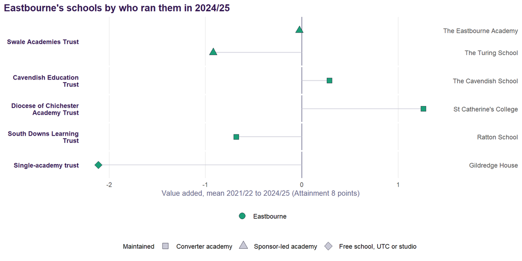

Figure 1: Who ran each school in 2024/25, and how far its results sat above or below the national model’s expectation over 2021/22 to 2024/25.

# 3 How Eastbourne compares

Eastbourne against East Sussex, Brighton and Hove and England, 2024/25. Means of school-level figures.

| Measure | Eastbourne | East Sussex | Brighton and Hove | England |
| --- | --- | --- | --- | --- |
| Attainment 8, all pupils | 42.7 | 43.8 | 45.5 | 46.8 |
| Attainment 8, disadvantaged | 33.2 | 33.0 | 33.9 | 37.7 |
| Attainment 8, non-disadvantaged | 47.0 | 47.5 | 49.6 | 49.9 |
| Disadvantage gap (points) | 13.9 | 14.5 | 15.7 | 12.2 |
| Disadvantaged (FSM6) % | 30.0 | 25.5 | 28.8 | 28.4 |
| Overall absence % | 9.4 | 9.7 | 11.3 | 8.6 |
| Persistent absence % | 24.6 | 26.4 | 30.6 | 23.9 |
| Mean KS2 (centred) | 2.67 | 3.79 | 4.71 | 4.47 |
| EAL % | 10.8 | 6.3 | 13.0 | 18.4 |

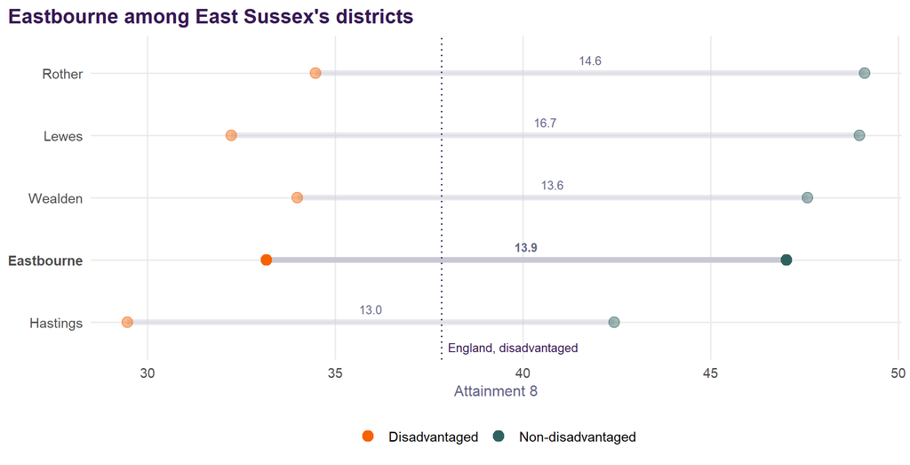

Figure 2: Attainment 8 for disadvantaged and non-disadvantaged pupils in East Sussex’s districts, 2024/25, school means. The gap between the two is printed on each district’s line; Eastbourne is in bold.

Across the years the model covers, the gap was 10.5 points in 2021/22 and 13.9 in 2024/25. Eastbourne’s non-disadvantaged pupils were above England’s average in 0 of 4 years, and its disadvantaged pupils in 0.

# 4 What explains attainment in Eastbourne

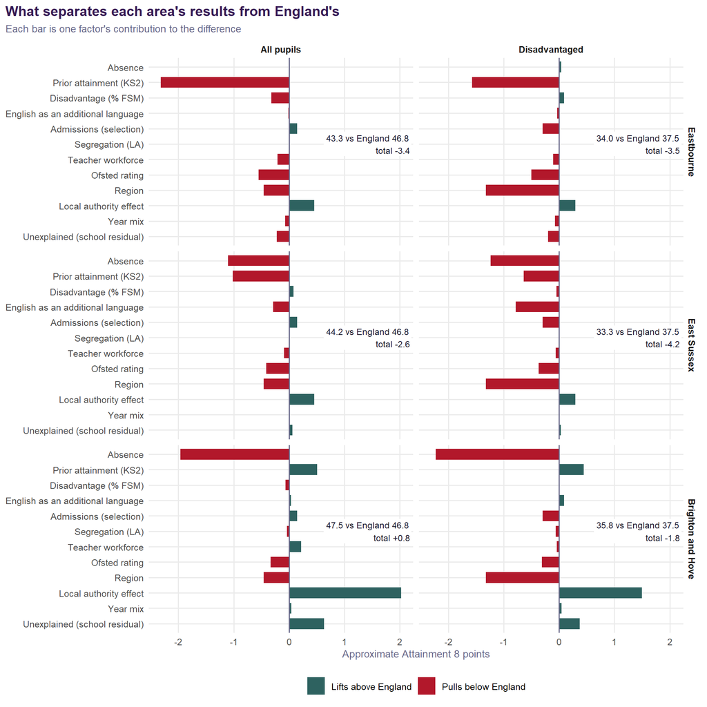

Figure 3: Why average Attainment 8 differs from England’s, by factor, all school-years 2021/22 to 2024/25, for Eastbourne, East Sussex and Brighton and Hove. Approximate Attainment 8 points; the pieces sum to the total in each panel.

The decomposition for Eastbourne, in Attainment 8 points. ‘Place’ is East Sussex’s effect plus the South East’s; ‘unexplained’ is what the district’s own schools add beyond everything the model accounts for.

| Factor | All pupils | Disadvantaged | Non-disadvantaged |
| --- | --- | --- | --- |
| Prior attainment (KS2) | -2.32 | -1.57 | -2.23 |
| Ofsted rating | -0.55 | -0.50 | -0.51 |
| Disadvantage (% FSM) | -0.32 | +0.09 | -0.13 |
| Unexplained (school residual) | -0.22 | -0.20 | -0.12 |
| Teacher workforce | -0.21 | -0.10 | -0.23 |
| English as an additional language | -0.01 | -0.03 | -0.02 |
| Absence | -0.00 | +0.04 | +0.03 |
| Place (region and local authority) | -0.00 | -1.03 | +0.28 |
| Other model terms | +0.08 | -0.38 | +0.06 |

**For all pupils**, Eastbourne is 3.4 points below England. The pieces of at least a quarter of a point:

- prior attainment (-2.32);
- Ofsted ratings (-0.55);
- being in the South East (-0.46);
- East Sussex’s county-wide effect (+0.46);
- the level of disadvantage (-0.32);
- and the district’s schools themselves (-0.22), beyond what the model expects.

**For disadvantaged pupils**, Eastbourne is 3.5 points below England. The pieces of at least a quarter of a point:

- prior attainment (-1.57);
- being in the South East (-1.32);
- Ofsted ratings (-0.50);
- admissions (-0.30);
- East Sussex’s county-wide effect (+0.29);
- and the district’s schools themselves (-0.20), beyond what the model expects.

# 5 The disadvantaged gap, school by school

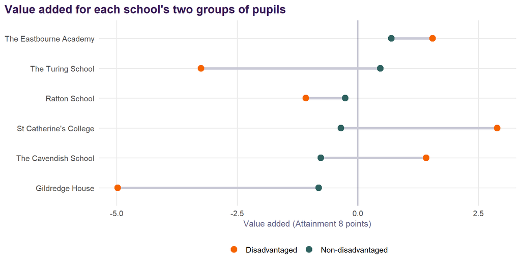

Figure 4: Each school’s value added for its disadvantaged and non-disadvantaged pupils, mean over the years available (2021/22 to provisional 2025/26). Above zero means better than the national model expects for similar pupils.

1 of the 6 schools is above expectation for non-disadvantaged pupils and more than a point below it for disadvantaged ones: The Turing School. The Eastbourne Academy is above expectation for both groups. The table below gives each school’s own persistent effect, from the model with a school term, which is the steadier measure.

Table 1: Each school’s own persistent effect on the national model with a school term (%), for each group of pupils and for absence beyond what its intake predicts. Positive absence is worse.

| School | All pupils | Disadvantaged | Non-disadvantaged | Absence (stage 1) |
| --- | --- | --- | --- | --- |
| The Eastbourne Academy | -1.3 | +3.7 | -2.2 | +12.8 |
| Ratton School | +0.0 | -2.3 | -0.8 | -12.0 |
| The Cavendish School | +3.1 | +6.3 | +1.1 | -32.1 |
| Gildredge House | -1.3 | -9.3 | -0.2 | -24.5 |
| St Catherine's College | +3.9 | +8.5 | +1.3 | +1.4 |
| The Turing School | -3.4 | -6.4 | +2.9 | +33.2 |

Table 2: Attainment 8 of each school’s disadvantaged pupils, year by year (2025/26 provisional), with the size of the group in 2024/25. Small groups make single years unreliable.

| School | 2021/22 | 2022/23 | 2023/24 | 2024/25 | 2025/26 | Disadvantaged pupils, 2024/25 |
| --- | --- | --- | --- | --- | --- | --- |
| The Cavendish School | 44.2 | 41.6 | 40.6 | 41.3 | 39.1 | 44 |
| The Eastbourne Academy | 33.7 | 29.5 | 24.2 | 32.3 | 29.7 | 67 |
| Gildredge House | 31.0 | 31.5 | 36.6 | 35.1 | 37.1 | 33 |
| Ratton School | 43.7 | 32.6 | 31.3 | 29.8 | 34.2 | 55 |
| St Catherine's College | 45.2 | 35.5 | 39.0 | 38.4 | 36.1 | 47 |
| The Turing School |  |  | 23.3 | 22.1 | 24.3 | 56 |

# 6 Is there an Eastbourne effect?

The district test of the East Sussex document adds a district level to the national model, with and without each school’s own record.

Table 3: The Eastbourne district effect, over and above East Sussex’s, with 95% intervals.

| Specification | Outcome | Effect (%) | 95% interval | Significant |
| --- | --- | --- | --- | --- |
| Published specification | All pupils | +0.3 | -3.1 to +3.7 | No |
| Published specification | Disadvantaged | +0.1 | -3.9 to +4.2 | No |
| Published specification | Non-disadvantaged | +0.4 | -2.6 to +3.4 | No |
| Published specification | Absence (stage 1) | -8.2 | -14.5 to -1.3 | Yes |
| With a school term | All pupils | +0.1 | -3.2 to +3.4 | No |
| With a school term | Disadvantaged | -0.1 | -3.1 to +3.1 | No |
| With a school term | Non-disadvantaged | +0.3 | -3.0 to +3.8 | No |
| With a school term | Absence (stage 1) | -1.2 | -6.8 to +4.7 | No |

On the published model, Eastbourne differs from the rest of East Sussex for absence (-8.2%). With each school’s own record in the model, none of that remains: the difference belongs to particular schools, not to the district as a place.

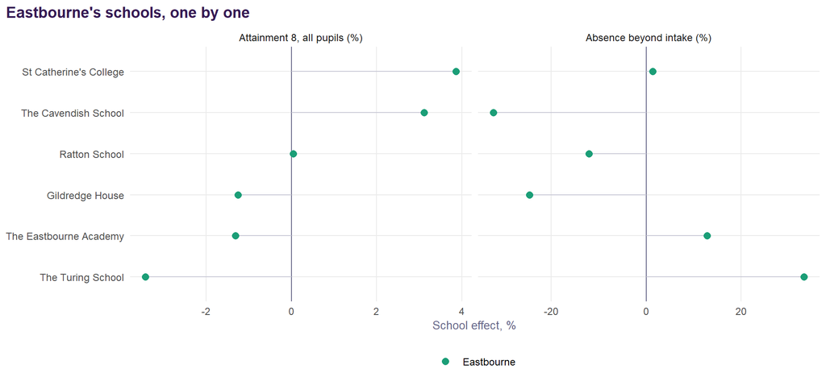

Figure 5: Each school’s own persistent effect, from the model with a school term: Attainment 8 for all pupils, and absence beyond what its intake predicts.

# 7 Absence

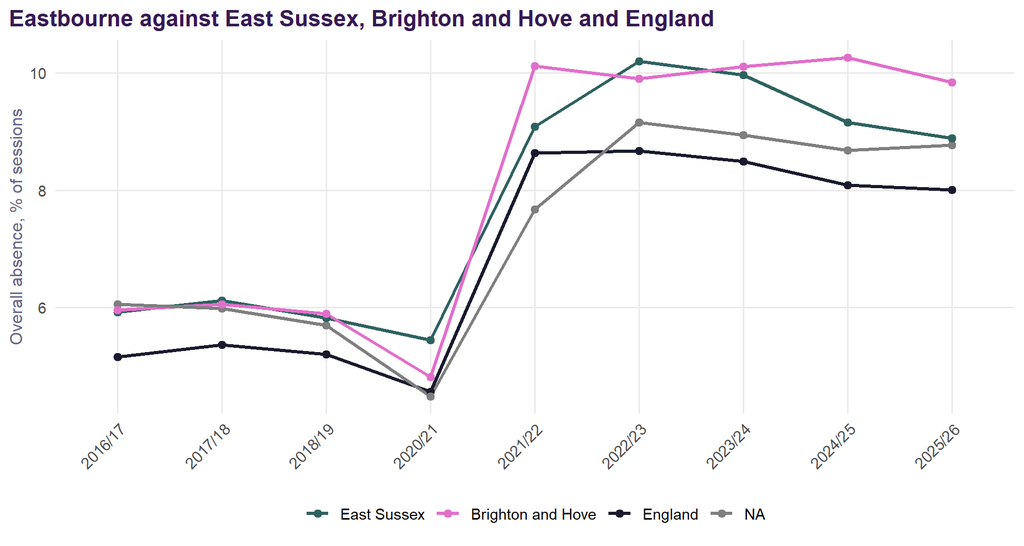

Figure 6: Overall absence, autumn and spring terms, 2016/17 to 2025/26. Sessions-weighted; 2019/20 not collected.

- **8.8% absence** in autumn and spring 2025/26, against 8.0% for England and 8.9% for East Sussex. A year earlier it was 8.7%.
- **Persistent absence** is 23.1%, against 21.6% for England.
- **Against its intake**, the district’s schools run 0.40 points below what their pupils’ profiles predict, on average over 2021/22 to 2024/25.

Table 4: Each school’s absence against what its intake predicts, mean 2021/22 to 2024/25, and its reasons in the latest year (percentage of sessions).

| School | Absence % | Predicted by intake % | Above prediction | Illness | Unauthorised | Reduced timetable | Suspended |
| --- | --- | --- | --- | --- | --- | --- | --- |
| The Turing School | 14.9 | 11.5 | +3.4 | 3.5 | 6.1 | 0.09 | 0.95 |
| The Eastbourne Academy | 12.2 | 11.3 | +0.9 | 3.6 | 4.4 | 1.22 | 1.28 |
| St Catherine's College | 9.3 | 9.2 | +0.1 | 4.2 | 1.8 | 0.61 | 0.34 |
| Ratton School | 8.2 | 9.4 | -1.2 | 4.7 | 3.2 | 0.42 | 0.33 |
| Gildredge House | 6.6 | 9.0 | -2.4 | 4.7 | 1.0 | 0.33 | 0.04 |
| The Cavendish School | 6.1 | 9.4 | -3.3 | 3.0 | 1.1 | 0.19 | 0.02 |

- **The Turing School** runs more than a point above its predicted absence.
- **The Cavendish School, Gildredge House and Ratton School** run more than a point below their predictions.

Reduced timetables account for 0.45% of sessions, against 0.29% in England, 1.5 times the national rate. The Eastbourne Academy’s rate is the highest in the district.

Table 5: Predicted Attainment 8 gain if each school’s absence fell to the national school average (2024/25). Indicative only.

| School | District | Absence % | FSM % | Gain, all pupils | Gain, disadvantaged | Gain from FSM to area average |
| --- | --- | --- | --- | --- | --- | --- |
| The Turing School | Eastbourne | 15.0 | 44.8 | +4.3 | +4.0 | +0.7 |
| The Eastbourne Academy | Eastbourne | 10.8 | 41.9 | +1.9 | +2.4 | +0.6 |
| Ratton School | Eastbourne | 9.1 | 23.3 | +0.5 | +0.5 | +0.0 |
| St Catherine's College | Eastbourne | 8.7 | 21.9 | +0.1 | +0.2 | +0.0 |

4 of the 6 schools are above the national average absence in 2024/25. Bringing them to it would add up to 4.3 points for all pupils, as an indication of scale.

**Suspensions** were 24.9 episodes per 100 pupils in 2024/25, against 21.2 for England and 28.0 for East Sussex. A rate per 100 pupils counts suspension episodes rather than pupils, and one pupil can be suspended several times in a year, so it is not a percentage of children: 8.0 pupils per 100 were suspended at least once, about 3.1 times each, against 7.3 per 100 and 2.9 times in England.

Table 6: Suspension episodes per 100 pupils, pupils suspended at least once per 100, and permanent exclusions, by school, latest year. One pupil can be suspended more than once, so the first rate runs well above the second.

| School | Pupils | Episodes per 100 | Pupils suspended per 100 | Permanent exclusions |
| --- | --- | --- | --- | --- |
| The Eastbourne Academy | 800 | 48.9 | 13.8 | 6 |
| St Catherine's College | 1072 | 44.1 | 12.2 | 1 |
| The Turing School | 765 | 34.0 | 9.9 | 1 |
| Ratton School | 1197 | 22.9 | 8.6 | 0 |
| The Cavendish School | 1372 | 7.8 | 2.8 | 0 |
| Gildredge House | 1168 | 6.8 | 4.7 | 0 |

# 8 Contextual league tables

**All pupils**

Value added, all pupils: observed Attainment 8 minus the national model’s expectation. 2025/26 is provisional.

| School | 2021/22 | 2022/23 | 2023/24 | 2024/25 | 2025/26 | Mean | Years |
| --- | --- | --- | --- | --- | --- | --- | --- |
| St Catherine's College | +5.2 | -1.9 | +1.1 | +0.2 | -2.0 | +0.5 | 5 |
| The Eastbourne Academy | +0.4 | +0.4 | -4.0 | +2.7 | +2.9 | +0.5 | 5 |
| Ratton School | -0.3 | -0.3 | -2.2 | -0.3 | +2.5 | -0.1 | 5 |
| The Cavendish School | +0.6 | -0.4 | +1.7 | -1.3 | -3.0 | -0.5 | 5 |
| Gildredge House | -4.1 | -2.4 | -0.3 | -1.5 | +0.2 | -1.6 | 5 |
| The Turing School |  |  | -3.4 | +1.6 | -3.7 | -1.9 | 3 |

**Disadvantaged pupils**

Value added, disadvantaged pupils. Small groups; read across years.

| School | 2021/22 | 2022/23 | 2023/24 | 2024/25 | 2025/26 | Mean | Years |
| --- | --- | --- | --- | --- | --- | --- | --- |
| St Catherine's College | +9.3 | +0.3 | +3.3 | +2.6 | -1.0 | +2.9 | 5 |
| The Eastbourne Academy | +1.2 | +2.0 | -1.8 | +4.2 | +2.2 | +1.6 | 5 |
| The Cavendish School | +2.2 | +1.8 | +2.5 | +2.8 | -2.2 | +1.4 | 5 |
| Ratton School | +2.5 | -2.7 | -2.6 | -3.5 | +0.9 | -1.1 | 5 |
| The Turing School |  |  | -2.8 | -3.4 | -3.6 | -3.3 | 3 |
| Gildredge House | -9.9 | -8.4 | -1.9 | -3.1 | -1.6 | -5.0 | 5 |

**Non-disadvantaged pupils**

Value added, non-disadvantaged pupils.

| School | 2021/22 | 2022/23 | 2023/24 | 2024/25 | 2025/26 | Mean | Years |
| --- | --- | --- | --- | --- | --- | --- | --- |
| The Eastbourne Academy | -0.0 | +0.8 | -5.0 | +2.3 | +5.3 | +0.7 | 5 |
| The Turing School |  |  | -2.3 | +7.0 | -3.4 | +0.5 | 3 |
| Ratton School | -1.0 | -0.4 | -2.5 | +0.1 | +2.5 | -0.3 | 5 |
| St Catherine's College | +3.8 | -2.8 | +0.1 | -0.8 | -2.0 | -0.4 | 5 |
| The Cavendish School | +0.3 | -0.6 | +1.7 | -2.4 | -2.8 | -0.8 | 5 |
| Gildredge House | -3.0 | -0.0 | +0.1 | -1.3 | +0.2 | -0.8 | 5 |

# 9 Questions for discussion

# Notes on method

Methods and sources are those of the East Sussex document. District membership comes from each school’s postcode (ONS postcode directory, via postcodes.io). Absence and exclusions for the district are summed over its schools, including any predecessor or successor URNs. This document is generated from `templates/district_report.qmd` by `R/20_district_reports.R`, from data built by `R/17_area_analysis.R`, `R/18_district_effects.R` and `R/19_trust_effects.R`. Its format is described in `AREA_REPORTS.md`.